# Hypothesis Testing Case Study | Yulu

**Context:** Yulu is India’s leading micro-mobility service provider, which offers unique vehicles for the daily commute. Starting off as a mission to eliminate traffic congestion in India, Yulu provides the safest commute solution through a user-friendly mobile app to enable shared, solo and sustainable commuting.

Yulu zones are located at all the appropriate locations (including metro stations, bus stands, office spaces, residential areas, corporate offices, etc) to make those first and last miles smooth, affordable, and convenient!

**Objective:** Yulu has recently suffered considerable dips in its revenues. They have contracted a consulting company to understand the factors on which the demand for these shared electric cycles depends. Specifically, they want to understand the factors affecting the demand for these shared electric cycles in the Indian market.

**Column Description:**

- datetime: datetime
- season: season (1: spring, 2: summer, 3: fall, 4: winter)
- holiday: whether day is a holiday or not (extracted from http://dchr.dc.gov/page/holiday-schedule)
- workingday: if day is neither weekend nor holiday is 1, otherwise is 0.
- weather:
  1. Clear, Few clouds, partly cloudy, partly cloudy
  2. Mist + Cloudy, Mist + Broken clouds, Mist + Few clouds, Mist
  3. Light Snow, Light Rain + Thunderstorm + Scattered clouds, Light Rain + Scattered clouds
  4. Heavy Rain + Ice Pallets + Thunderstorm + Mist, Snow + Fog
- temp: temperature in Celsius
- atemp: feeling temperature in Celsius
- humidity: humidity
- windspeed: wind speed
- casual: count of casual users
- registered: count of registered users
- count: count of total rental bikes including both casual and registered

### Importing Libraries

```python
import numpy as np
import pandas as pd
import scipy.stats as stats
import matplotlib.pyplot as plt
import seaborn as sns

from scipy import stats

plt.rcParams['figure.figsize'] = (8, 6)
plt.rcParams['figure.dpi'] = 150

cmap_seagreen = sns.light_palette("seagreen", as_cmap=True)
sns.set_theme(palette="pastel")
```

## Loading CSV File

```python
df = pd.read_csv("/content/drive/MyDrive/Scaler/Yulu Case Study/yulu_bike_sharing.csv")
print(df.shape, df.isna().sum().sum(), df.duplicated().sum(), df.nunique().sort_values(), sep="\n\n")
df.head()
```

```
(10886, 12)

0

0

holiday           2
workingday        2
season            4
weather           4
windspeed        28
temp             49
atemp            60
humidity         89
casual          309
registered      731
count           822
datetime      10886
dtype: int64
```

|  | datetime | season | holiday | workingday | weather | temp | atemp | humidity | windspeed | casual | registered | count |
| --- | --- | --- | --- | --- | --- | --- | --- | --- | --- | --- | --- | --- |
| 0 | 2011-01-01 00:00:00 | 1 | 0 | 0 | 1 | 9.84 | 14.395 | 81 | 0.0 | 3 | 13 | 16 |
| 1 | 2011-01-01 01:00:00 | 1 | 0 | 0 | 1 | 9.02 | 13.635 | 80 | 0.0 | 8 | 32 | 40 |
| 2 | 2011-01-01 02:00:00 | 1 | 0 | 0 | 1 | 9.02 | 13.635 | 80 | 0.0 | 5 | 27 | 32 |
| 3 | 2011-01-01 03:00:00 | 1 | 0 | 0 | 1 | 9.84 | 14.395 | 75 | 0.0 | 3 | 10 | 13 |
| 4 | 2011-01-01 04:00:00 | 1 | 0 | 0 | 1 | 9.84 | 14.395 | 75 | 0.0 | 0 | 1 | 1 |

```python
#print(df.info(), "\n\n")
df.describe()
```

|  | season | holiday | workingday | weather | temp | atemp | humidity | windspeed | casual | registered | count |
| --- | --- | --- | --- | --- | --- | --- | --- | --- | --- | --- | --- |
| count | 10886.000000 | 10886.000000 | 10886.000000 | 10886.000000 | 10886.00000 | 10886.000000 | 10886.000000 | 10886.000000 | 10886.000000 | 10886.000000 | 10886.000000 |
| mean | 2.506614 | 0.028569 | 0.680875 | 1.418427 | 20.23086 | 23.655084 | 61.886460 | 12.799395 | 36.021955 | 155.552177 | 191.574132 |
| std | 1.116174 | 0.166599 | 0.466159 | 0.633839 | 7.79159 | 8.474601 | 19.245033 | 8.164537 | 49.960477 | 151.039033 | 181.144454 |
| min | 1.000000 | 0.000000 | 0.000000 | 1.000000 | 0.82000 | 0.760000 | 0.000000 | 0.000000 | 0.000000 | 0.000000 | 1.000000 |
| 25% | 2.000000 | 0.000000 | 0.000000 | 1.000000 | 13.94000 | 16.665000 | 47.000000 | 7.001500 | 4.000000 | 36.000000 | 42.000000 |
| 50% | 3.000000 | 0.000000 | 1.000000 | 1.000000 | 20.50000 | 24.240000 | 62.000000 | 12.998000 | 17.000000 | 118.000000 | 145.000000 |
| 75% | 4.000000 | 0.000000 | 1.000000 | 2.000000 | 26.24000 | 31.060000 | 77.000000 | 16.997900 | 49.000000 | 222.000000 | 284.000000 |
| max | 4.000000 | 1.000000 | 1.000000 | 4.000000 | 41.00000 | 45.455000 | 100.000000 | 56.996900 | 367.000000 | 886.000000 | 977.000000 |

## Data Cleaning and Feature Extraction

```python
# Updating data type before checking corelation
df["datetime"] = pd.to_datetime(df["datetime"])

# insert() was used to place the columns in the beginning
df.insert(1, 'year', df['datetime'].dt.year)
df.insert(2, 'month', pd.to_numeric(df['datetime'].dt.strftime('%m')))
df.insert(3, 'day', df['datetime'].dt.day)
df.insert(4, 'weekday', pd.to_numeric(df['datetime'].dt.strftime('%w')))
df.insert(5, 'hour', df['datetime'].dt.hour)


df["workingday"] = df["workingday"] == 1
df["holiday"] = df["holiday"] == 1
```

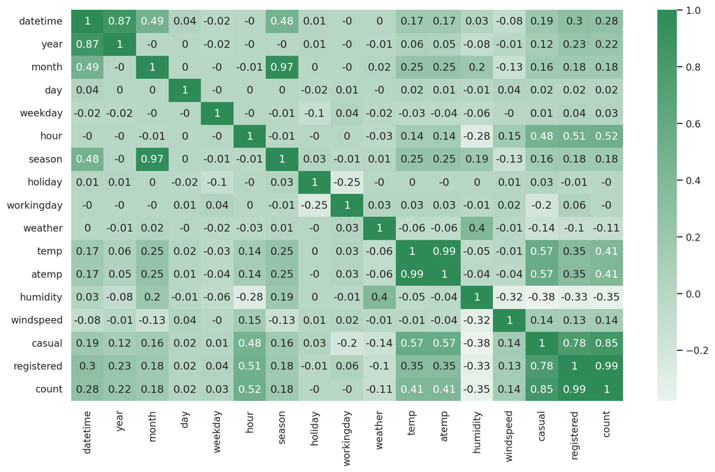

```python
# Checking corelation before modifing numerical columns

data = round(df.corr(method='spearman'), 2)

plt.figure(figsize=(14, 8))
sns.heatmap(data, annot=True, cmap=cmap_seagreen)
plt.show()
```

```python
categorical_columns = ["holiday", "workingday", "season", "weather"]
for col in categorical_columns:
    print(df[col].value_counts().reset_index(), end="\n\n")
```

```
   holiday  count
0    False  10575
1     True    311

   workingday  count
0        True   7412
1       False   3474

   season  count
0       4   2734
1       2   2733
2       3   2733
3       1   2686

   weather  count
0        1   7192
1        2   2834
2        3    859
3        4      1
```

```python
# season mapping
season_mapping = {1: "Spring", 2: "Summer", 3: "Fall", 4: "Winter"}
df["season"] = df["season"].map(season_mapping)

# weather mapping
# The weather with only one instance can be grouped with other similar weather condition
weather_mapping = {
    1: "Clear/Partly cloudy", #Clear, Few clouds, partly cloudy
    2: "Mist/Cloudy", #Mist + Cloudy, Mist + Broken clouds, Mist + Few clouds, Mist
    3: "Light Snow/Rain + Thunder", # Light Snow, Light Rain + Thunderstorm + Scattered clouds, Light Rain + Scattered clouds

    # Merged because there is only one instance of this weather:
    4: "Light Snow/Rain + Thunder" # Heavy Rain + Ice Pallets + Thunderstorm + Mist, Snow + Fog
}
df["weather"] = df["weather"].map(weather_mapping)

# holiday mapping
def holiday_workingday(row):
    if (row["workingday"] == True) & (row["holiday"] == True):
        return "NA"
    elif (row["workingday"] == False) & (row["holiday"] == True):
        return "Holiday"
    elif (row["workingday"] == True) & (row["holiday"] == False):
        return "Work Day"
    elif (row["workingday"] == False) & (row["holiday"] == False):
        return "Weekend"
df["day_status"] = df.apply(holiday_workingday, axis=1)

# hour mapping
bins = [0, 3, 6, 9, 12, 15, 18, 21, 24]
labels = [
    "Midnight Hours", "Dawn", "Early Morning",
    "Morning", "Afternoon", "Late Afternoon",
    "Evening", "Night"
]
df["time_of_day"] = pd.cut(df["hour"], bins=bins, labels=labels, right=False)
```

```python
df.head()
```

|  | datetime | year | month | day | weekday | hour | season | holiday | workingday | weather | temp | atemp | humidity | windspeed | casual | registered | count | day_status | time_of_day |
| --- | --- | --- | --- | --- | --- | --- | --- | --- | --- | --- | --- | --- | --- | --- | --- | --- | --- | --- | --- |
| 0 | 2011-01-01 00:00:00 | 2011 | 1 | 1 | 6 | 0 | Spring | False | False | Clear/Partly cloudy | 9.84 | 14.395 | 81 | 0.0 | 3 | 13 | 16 | Weekend | Midnight Hours |
| 1 | 2011-01-01 01:00:00 | 2011 | 1 | 1 | 6 | 1 | Spring | False | False | Clear/Partly cloudy | 9.02 | 13.635 | 80 | 0.0 | 8 | 32 | 40 | Weekend | Midnight Hours |
| 2 | 2011-01-01 02:00:00 | 2011 | 1 | 1 | 6 | 2 | Spring | False | False | Clear/Partly cloudy | 9.02 | 13.635 | 80 | 0.0 | 5 | 27 | 32 | Weekend | Midnight Hours |
| 3 | 2011-01-01 03:00:00 | 2011 | 1 | 1 | 6 | 3 | Spring | False | False | Clear/Partly cloudy | 9.84 | 14.395 | 75 | 0.0 | 3 | 10 | 13 | Weekend | Dawn |
| 4 | 2011-01-01 04:00:00 | 2011 | 1 | 1 | 6 | 4 | Spring | False | False | Clear/Partly cloudy | 9.84 | 14.395 | 75 | 0.0 | 0 | 1 | 1 | Weekend | Dawn |

## Exploratory Data Analysis

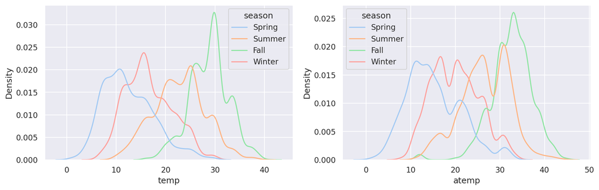

```python
fig = plt.figure(figsize=(14,4))

ax1 = fig.add_subplot(1,2,1)
sns.kdeplot(data=df, x=round(df["temp"]), hue="season", ax=ax1)

ax2 = fig.add_subplot(1,2,2)
sns.kdeplot(data=df, x=round(df["atemp"]), hue="season", ax=ax2)

plt.show()
```

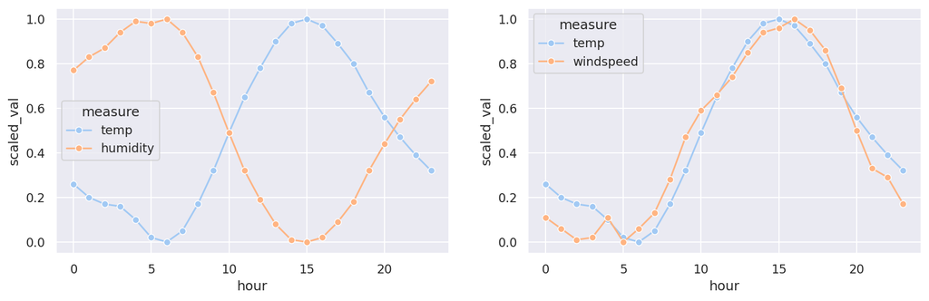

```python
def minMaxScaler(series, x=2):
    return round((series - series.min()) / (series.max() - series.min()), x)

fig = plt.figure(figsize=(14,4))

s1 = minMaxScaler(df.groupby("hour")["temp"].mean())
s2 = minMaxScaler(df.groupby("hour")["humidity"].mean())
data = pd.concat([s1,s2], axis=1).reset_index()
data = pd.melt(data, id_vars="hour", var_name="measure", value_name="scaled_val")

ax1 = fig.add_subplot(1,2,1)
sns.lineplot(data, x="hour", y="scaled_val", hue="measure", marker="o", ax=ax1)

s3 = minMaxScaler(df.groupby("hour")["windspeed"].mean())
data = pd.concat([s1,s3], axis=1).reset_index()
data = pd.melt(data, id_vars="hour", var_name="measure", value_name="scaled_val")

ax2 = fig.add_subplot(1,2,2)
sns.lineplot(data, x="hour", y="scaled_val", hue="measure", marker="o", ax=ax2)

plt.show()
```

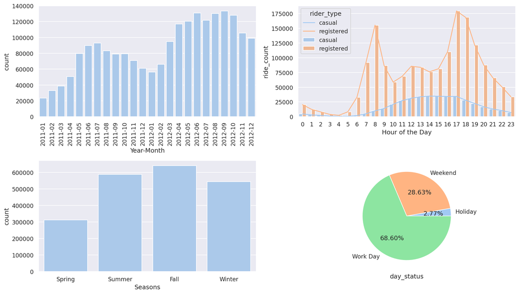

```python
fig = plt.figure(figsize = (14, 8))


month_year = df['datetime'].dt.strftime('%Y-%m')
# Remember when passing series to sns plots, it will treat the index as the x-axis and the values as the y-axis
# If I reset_index() after sum(), then i will have to explicetly specify both the axes
ax1 = fig.add_subplot(2,2,1)
sns.barplot(df.groupby(month_year)["count"].sum(), ax=ax1)
ax1.tick_params(axis='x', rotation=90)
ax1.set_xlabel("Year-Month")

data = df.melt(id_vars="hour", value_vars=["casual", "registered"], var_name="rider_type", value_name="ride_count")
data = data.groupby(["hour", "rider_type"])["ride_count"].sum().reset_index()
ax2 = fig.add_subplot(2,2,2)
sns.lineplot(data=data, x="hour", y="ride_count", ax=ax2, hue="rider_type")
sns.barplot(data=data, x="hour", y="ride_count", ax=ax2, hue="rider_type")
ax2.set_xlabel("Hour of the Day")

ax3 = fig.add_subplot(2,2,3)
sns.barplot(df.groupby("season")["count"].sum(), ax=ax3, order=["Spring", "Summer", "Fall", "Winter"])
ax3.set_xlabel("Seasons")

ax4 = fig.add_subplot(2,2,4)
day_status_data = df.groupby("day_status")["count"].sum()
ax4.pie(day_status_data, labels=day_status_data.index, autopct='%1.2f%%')
ax4.set_xlabel("day_status")

plt.tight_layout()
plt.show()
```

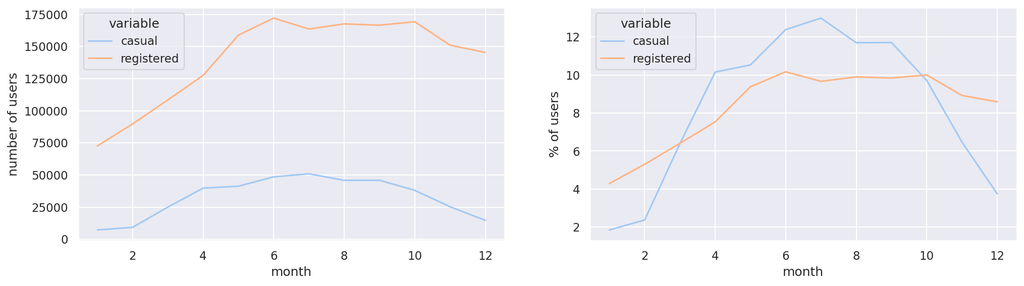

```python
data = df.groupby(["month"])[["casual", "registered"]].sum().reset_index()
data = data.melt(id_vars=["month"])
fig = plt.figure(figsize=(16,4))

ax1 = fig.add_subplot(1,2,1)
sns.lineplot(data, x="month", y="value", hue="variable", ax=ax1)
ax1.set_ylabel("number of users")

data = df.groupby(["month"])[["casual", "registered"]].sum().reset_index()
data["casual"] = data["casual"] / data["casual"].sum() * 100
data["registered"] = data["registered"] / data["registered"].sum() * 100
data = data.melt(id_vars=["month"])

ax2 = fig.add_subplot(1,2,2)
sns.lineplot(data, x="month", y="value", hue="variable", ax=ax2)
ax2.set_ylabel("% of users")

plt.show()
```

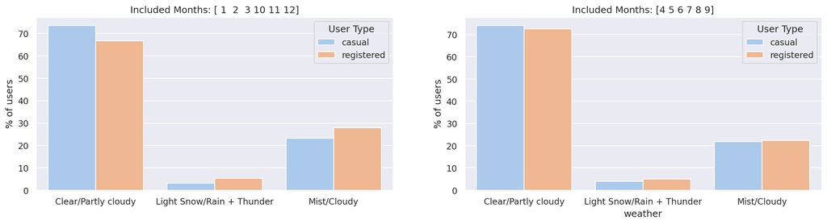

```python
data = df.loc[~df["month"].between(4,9)]
months = data["month"].unique()
data = data.groupby(["weather"])[["casual", "registered"]].sum().reset_index()
data["casual"] = data["casual"] / data["casual"].sum() * 100
data["registered"] = data["registered"] / data["registered"].sum() * 100
data = data.melt(id_vars=["weather"])
data.columns = ["weather", "User Type", "% of users"]

fig = plt.figure(figsize=(18, 4))

ax1 = fig.add_subplot(1,2,1)
sns.barplot(data, x="weather", y="% of users", hue="User Type", ax=ax1)
ax1.set_title(f"Included Months: {months}")
ax1.set_xlabel("")

data = df.loc[df["month"].between(4,9)]
months = data["month"].unique()
data = data.groupby(["weather"])[["casual", "registered"]].sum().reset_index()
data["casual"] = data["casual"] / data["casual"].sum() * 100
data["registered"] = data["registered"] / data["registered"].sum() * 100
data = data.melt(id_vars=["weather"])
data.columns = ["weather", "User Type", "% of users"]

ax2 = fig.add_subplot(1,2,2)
sns.barplot(data, x="weather", y="% of users", hue="User Type", ax=ax2)
ax2.set_title(f"Included Months: {months}")
ax1.set_xlabel("")

plt.show()
```

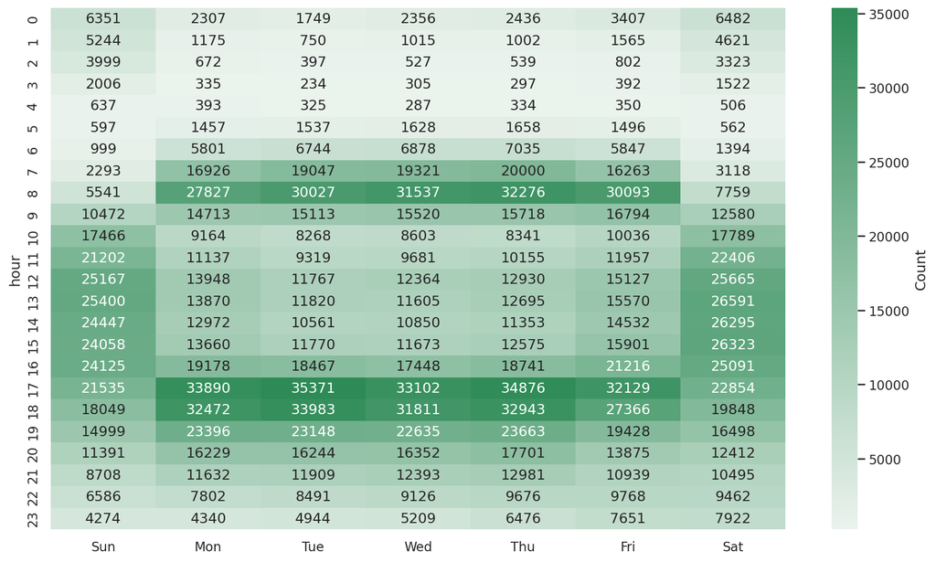

```python
#data = df.loc[df["day_status"] == "Holiday on Weekend"]
data = df.groupby(['weekday', 'hour'])['count'].sum().reset_index()
data = data.pivot(index='hour', columns='weekday', values='count')
data.columns = ['Sun', 'Mon', 'Tue', 'Wed', 'Thu', 'Fri', 'Sat']

plt.figure(figsize=(14,8))
sns.heatmap(data, cmap=cmap_seagreen, annot=True, fmt='g', cbar_kws={'label': 'Count'})
plt.show()
```

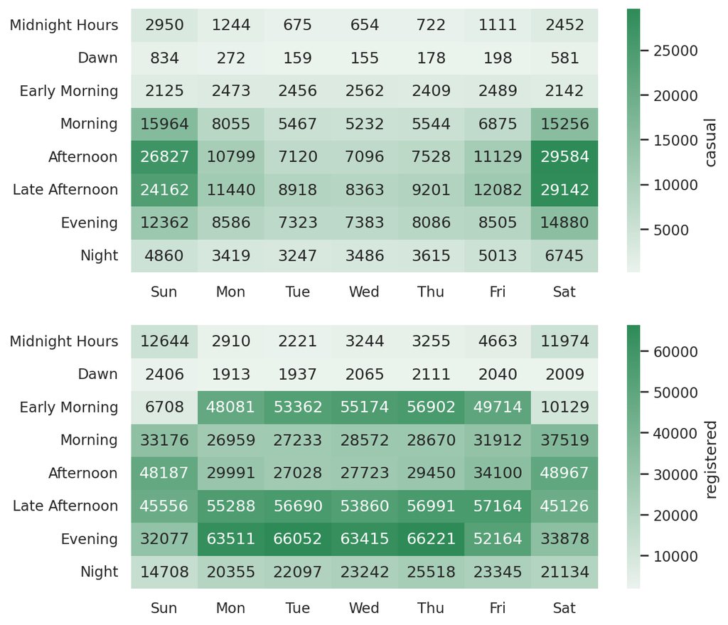

```python
cols = ["casual", "registered"]
fig = plt.figure(figsize=(8,8))

for i in range(len(cols)):
    col = cols[i]
    data = df#.loc[df["day_status"] == "Holiday"]
    data = data.groupby(['weekday', 'time_of_day'], observed=False)[col].sum().reset_index()
    data = data.pivot(index='weekday', columns='time_of_day', values=col)
    data.columns.name = None
    data = data[[ "Midnight Hours", "Dawn", "Early Morning", "Morning", "Afternoon", "Late Afternoon", "Evening", "Night"]]
    data.index = ['Sun', 'Mon', 'Tue', 'Wed', 'Thu', 'Fri', 'Sat']

    fig.add_subplot(2,1,i+1)
    sns.heatmap(data.T, cmap=cmap_seagreen, annot=True, fmt='g', cbar_kws={'label': col})

plt.show()
```

## Hypothesis Testing

### Test 1

- Null Hypothesis ($H_o$): The average number of rides on working days is >= number of rides on non working days.
- Alternative Hypothesis ($H_a$): The average number of rides on working days is < number of rides on non working days.
- Significance Level α = 0.05

```python
notworkday = df[df['day_status'] != "Work Day"]['count']
# Unequal sample sizes can lead to unequal variances
# Because notworkday are less than workday, only notworkday.count() samples are being used
workday = df[df['day_status'] == "Work Day"]['count'].sample(notworkday.count())

test_stat, pvalue = stats.levene(workday, notworkday)
print(f"pvalue is {round(pvalue,2)}, implying","similar variances" if pvalue > 0.05 else "non-similar variances")
```

```
pvalue is 0.79, implying similar variances
```

```python
test_stat, pvalue = stats.ttest_ind(workday, notworkday, alternative="less")
print(
    f"pvalue is {round(pvalue,2)}, implying we",
    "failed to reject null hypothesis and \nthe number of rides on working days is >= number of rides on non working days"
    if pvalue > 0.05 else
    "reject null hypothesis and \nthe number of rides on working days is < number of rides on non working days"
)
```

```
pvalue is 0.88, implying we failed to reject null hypothesis and
the number of rides on working days is >= number of rides on non working days
```

### Test 2

- Null Hypothesis ($H_o$): The average number of rides is equal across all seasons. ( 𝜇1 = 𝜇2 = 𝜇3 = 𝜇4, where 𝜇1, 𝜇2, 𝜇3, 𝜇4 are the average ride count for four seasons.)
- Alternative Hypothesis ($H_a$): The average number of rides in at least one season is different. (At least one mean is not equal to the others.)
- Significance Level α = 0.05

```python
# For equal sample count
n = df["season"].value_counts().min()
s1 = df.loc[df["season"] == "Spring", "count"].sample(n)
s2 = df.loc[df["season"] == "Summer", "count"].sample(n)
s3 = df.loc[df["season"] == "Fall", "count"].sample(n)
s4 = df.loc[df["season"] == "Winter", "count"].sample(n)
```

```python
# Test for Normality
# Null Hypothesis ($H_o$): The data comes from a normal distribution.
# Alternative Hypothesis ($H_a$): The data does not come from a normal distribution.

print("s1 p-value", stats.shapiro(s1)[1])
print("s2 p-value", stats.shapiro(s2)[1])
print("s3 p-value", stats.shapiro(s3)[1])
print("s4 p-value", stats.shapiro(s4)[1])
```

```
s1 p-value 8.749584618867163e-49
s2 p-value 1.2834643863634394e-38
s3 p-value 2.1538609300321335e-36
s4 p-value 2.2724171145346608e-39
```

All p-values are < 0.05, therefore no season is normally distributed

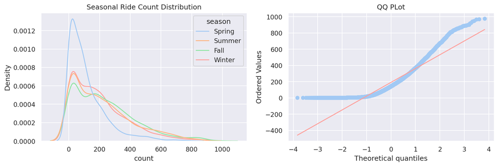

```
Skewness :  1.2420662117180776
Kurtosis :  1.3000929518398334
```

```python
# Visual analysis

fig = plt.figure(figsize=(14,4))

ax1 = fig.add_subplot(1,2,1)
sns.kdeplot(df, x="count", hue="season", ax=ax1)
ax1.set_title("Seasonal Ride Count Distribution")

ax2 = fig.add_subplot(1,2,2)
stats.probplot(df["count"], dist='norm', plot=ax2)
ax2.set_title("QQ PLot")

plt.show()

print("Skewness : ", df['count'].skew())
print("Kurtosis : ", df['count'].kurt())
```

```python
# Test for equal variance
# Null Hypothesis ($H_o$): The variances of the groups are equal.
# Alternative Hypothesis ($H_a$): At least one group has a variance that is significantly different from the others.

print("p-value:", stats.levene(s1, s2, s3, s4)[1])
```

```
p-value: 1.0335905377801708e-118
```

The p-value is < 0.05 therefore we reject the null hypothesis; At least one season has different variance

```python
stats.f_oneway(s1, s2, s3, s4)
```

```
F_onewayResult(statistic=237.97591286119527, pvalue=1.6714120471516456e-149)
```

**Observation:** As p-value is < 0.05 we reject the null hypothesis; The average number of rides in at least one season is different.

### Test 3

```python
# For equal sample count
n = df["weather"].value_counts().min()

w1, w2, w3 = df["weather"].value_counts().index

w1 = df.loc[df["weather"] == w1, "count"].sample(n)
w2 = df.loc[df["weather"] == w2, "count"].sample(n)
w3 = df.loc[df["weather"] == w3, "count"].sample(n)
```

```python
# Test for Normality
# Null Hypothesis ($H_o$): The data comes from a normal distribution.
# Alternative Hypothesis ($H_a$): The data does not come from a normal distribution.

print("w1 p-value", stats.shapiro(s1)[1])
print("w2 p-value", stats.shapiro(s2)[1])
print("w3 p-value", stats.shapiro(s3)[1])
```

```
w1 p-value 8.749584618867163e-49
w2 p-value 1.2834643863634394e-38
w3 p-value 2.1538609300321335e-36
```

All p-values are < 0.05, therefore no season is normally distributed

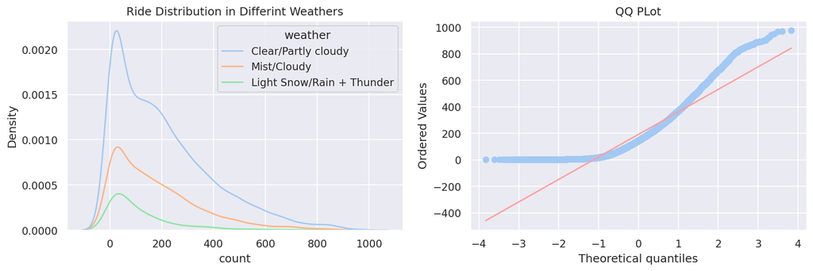

```
Skewness :  1.2420662117180776
Kurtosis :  1.3000929518398334
```

```python
# Visual analysis

fig = plt.figure(figsize=(14,4))

ax1 = fig.add_subplot(1,2,1)
sns.kdeplot(df, x="count", hue="weather", ax=ax1)
ax1.set_title("Ride Distribution in Differint Weathers")

ax2 = fig.add_subplot(1,2,2)
stats.probplot(df["count"], dist='norm', plot=ax2)
ax2.set_title("QQ PLot")

plt.show()

print("Skewness : ", df['count'].skew())
print("Kurtosis : ", df['count'].kurt())
```

```python
# Test for equal variance
# Null Hypothesis ($H_o$): The variances of the groups are equal.
# Alternative Hypothesis ($H_a$): At least one group has a variance that is significantly different from the others.

print("p-value:", stats.levene(w1, w2, w3)[1])
```

```
p-value: 1.9888027196987587e-20
```

The p-value is < 0.05 therefore we reject the null hypothesis; At least one season has different variance

```python
stats.f_oneway(w1, w2, w3)
```

```
F_onewayResult(statistic=64.46181844395787, pvalue=4.8123780735145934e-28)
```

**Observation:** As p-value is < 0.05 we reject the null hypothesis; The average number of rides in at least one weather is different.

### Test 4

- Null Hypothesis ($H_o$): The weather and seasons are independent (no association).
- Alternative Hypothesis ($H_a$): The weather and seasons are not independent (there is an association).
- Significance Level α = 0.05

```python
data = pd.crosstab(df['season'], df['weather'], values=df['count'], aggfunc='sum')
data
```

| weather season | Clear/Partly cloudy | Light Snow/Rain + Thunder | Mist/Cloudy |
| --- | --- | --- | --- |
| Fall | 470116 | 31160 | 139386 |
| Spring | 223009 | 13083 | 76406 |
| Summer | 426350 | 27755 | 134177 |
| Winter | 356588 | 30255 | 157191 |

```python
stats.chi2_contingency(data)
```

```
Chi2ContingencyResult(statistic=10788.223633468619, pvalue=0.0, dof=6, expected_freq=array([[453449.22392106,  31412.3065842 , 155800.46949473],
       [221180.55320416,  15322.09337053,  75995.35342531],
       [416375.58704392,  28844.06214505, 143062.35081104],
       [385057.63583086,  26674.53790022, 132301.82626892]]))
```

**Observation:** Since the p-value is less than the 0.05 significance level, we reject the null hypothesis. Hence, weather conditions are dependent on the ongoing season.

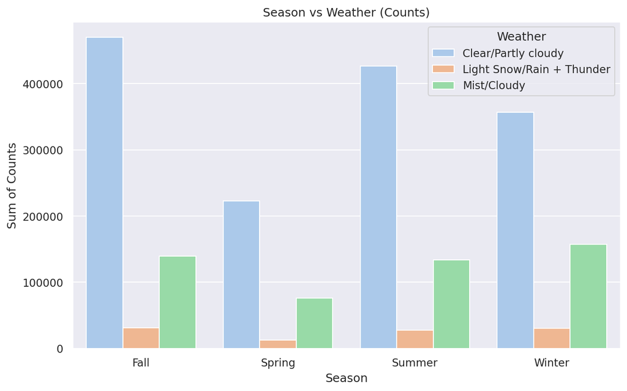

```python
crosstab_melt = data.reset_index().melt(id_vars='season', var_name='weather', value_name='count')

plt.figure(figsize=(10, 6))
sns.barplot(data=crosstab_melt, x='season', y='count', hue='weather')
plt.title("Season vs Weather (Counts)")
plt.xlabel("Season")
plt.ylabel("Sum of Counts")
plt.legend(title="Weather")
plt.show()
```

### Insights

- There was an inverse correlation between temperature and humidity.
- Around 70% of the rides are booked on working days.
- The number of registered riders is significantly higher than casual riders.
- The number of rides booked by registered users peaks around 8 am and 5 pm.
- The number of rides booked is highest in fall and summer. Additionally, casual riders highly prefer these months to ride.
- Most casual riders ride on Saturdays and Sundays; whereas most registered riders ride from Monday to Friday.

### Hypothesis Tests

**Test 1 (T-test independence)**

- Null Hypothesis ( Ho ): The average number of rides on working days is >= number of rides on non-working days.
- Alternative Hypothesis ( Ha ): The average number of rides on working days is < the number of rides on non-working days.
- **Observation:** p-value is 0.88, implying we failed to reject the null hypothesis and the number of rides on working days is >= number of rides on non-working days

**Test 2 (ANOVA)**

- Null Hypothesis ( Ho ): The average number of rides is equal across all seasons. ( 𝜇1 = 𝜇2 = 𝜇3 = 𝜇4, where 𝜇1, 𝜇2, 𝜇3, 𝜇4 are the average ride count for four seasons.)
- Alternative Hypothesis ( Ha ): The average number of rides in at least one season is different. (At least one mean is not equal to the others.) -**Observation:** As the p-value is < 0.05 we reject the null hypothesis; The average number of rides in at least one season is different.

**Test 4 (Chi-Square Test of Independence)**

- Null Hypothesis ( Ho ): The weather and seasons are independent (no association).
- Alternative Hypothesis ( Ha ): The weather and seasons are not independent (there is an association). -**Observation:** We reject the null hypothesis since the p-value is less than the 0.05 significance level. Hence, weather conditions are dependent on the ongoing season.

## Code for Saving Analysis File

```python
import subprocess
import os
from bs4 import BeautifulSoup

drive_source_file = "Scaler/Yulu Case Study/Yulu Case Study.ipynb"
style = """
    img{
        max-height: 30rem !important;
        max-width: 80vw !important;
        object-fit: contain;
    }
"""

def save_html_for_print(drive_source_file, style):
  command = f"jupyter nbconvert --to html '/content/drive/MyDrive/{drive_source_file}' --output '/content/temp.html'"
  result = subprocess.run(command, shell=True, text=True, capture_output=True)
  #print("STDOUT:", result.stdout, "\nSTDERR:", result.stderr, "\nReturn Code:", result.returncode)
  with open("/content/temp.html", "r") as file:
      html_content = file.read()
  soup = BeautifulSoup(html_content, "html.parser")
  style_tag = soup.new_tag("style")
  style_tag.string = style
  soup.head.append(style_tag)
  os.remove("/content/temp.html")
  new_file_path = f"/content/{drive_source_file.split('/')[-1].split('.')[0]}.html"
  with open(new_file_path, "w") as new_file:
      new_file.write(str(soup))

# self reminder: increase the DPI of sns plots before saving
save_html_for_print(drive_source_file, style)
```